# assignment6_imageclassification_cnn

```python
# Upgrade pip to the latest version
!pip install --upgrade pip

# Install TensorFlow
!pip install tensorflow
```

```
  Obtaining dependency information for pip from https://files.pythonhosted.org/packages/8a/6a/19e9fe04fca059ccf770861c7d5721ab4c2aebc539889e97c7977528a53b/pip-24.0-py3-none-any.whl.metadata
  Using cached pip-24.0-py3-none-any.whl.metadata (3.6 kB)
Using cached pip-24.0-py3-none-any.whl (2.1 MB)
```

[output not shown]

```python
# Import TensorFlow
import tensorflow as tf
```

```python
import os
import tarfile
import pickle
import numpy as np

import matplotlib.pyplot as plt
```

```python
from tensorflow.keras.preprocessing.image import ImageDataGenerator
```

# Data for HW - read up on CIFAR dataset at https://www.cs.toronto.edu/~kriz/cifar.html

# 1. Data Processing

```python
import os
import tarfile

# Step 1: Extract the contents of the archive
dataset_dir = 'C:/Users/gongl1/Desktop/Machine Learning - Bose/Assignment 6/extracted dataset folder'  # path to the extracted dataset folder
archive_path = 'C:/Users/gongl1/Desktop/Machine Learning - Bose/Assignment 6/cifar-10-python.tar.gz'  # path to the downloaded archive

if not os.path.exists(dataset_dir):
    print("Creating dataset directory:", dataset_dir)
    os.makedirs(dataset_dir)

if os.path.exists(archive_path):
    print("Archive file exists. Extracting contents...")
    try:
        with tarfile.open(archive_path, 'r:gz') as tar:
            tar.extractall(path=dataset_dir)
        print("Extraction completed successfully.")
    except Exception as e:
        print("Error occurred during extraction:", e)
else:
    print("Archive file does not exist. Please check the path:", archive_path)
```

```
Archive file exists. Extracting contents...
Extraction completed successfully.
```

```python
# Function to unpickle the CIFAR-10 data
def unpickle(file):
    with open(file, 'rb') as fo:
        dict = pickle.load(fo, encoding='bytes')
    return dict
```

```python
# Path to the extracted dataset folder
dataset_dir = 'C:/Users/gongl1/Desktop/Machine Learning - Bose/Assignment 6/extracted dataset folder/cifar-10-batches-py'
```

```python
# Define the directory structure for the training and validation sets
train_dir = os.path.join(dataset_dir, 'train')
validation_dir = os.path.join(dataset_dir, 'validation')
```

```python
# Create train and validation directories if they don't exist
for directory in [train_dir, validation_dir]:
    if not os.path.exists(directory):
        os.makedirs(directory)
```

```python
# Load the CIFAR-10 training data batches and split into train and validation sets
for i in range(1, 6):
    batch_file = os.path.join(dataset_dir, f'data_batch_{i}')
    train_batch = unpickle(batch_file)
    train_images = train_batch[b'data'].reshape(-1, 3, 32, 32).transpose(0, 2, 3, 1)
    train_labels = np.array(train_batch[b'labels'])

    # Split train data into train and validation sets (80% train, 20% validation)
    num_train_samples = int(len(train_images) * 0.8)
    train_images_split = train_images[:num_train_samples]
    train_labels_split = train_labels[:num_train_samples]
    validation_images = train_images[num_train_samples:]
    validation_labels = train_labels[num_train_samples:]

    # Save train images to train directory
    for j in range(len(train_images_split)):
        image_path = os.path.join(train_dir, f'class_{train_labels_split[j]}', f'image_{i}_{j}.png')
        os.makedirs(os.path.dirname(image_path), exist_ok=True)
        plt.imsave(image_path, train_images_split[j])

    # Save validation images to validation directory
    for j in range(len(validation_images)):
        image_path = os.path.join(validation_dir, f'class_{validation_labels[j]}', f'image_{i}_{j}.png')
        os.makedirs(os.path.dirname(image_path), exist_ok=True)
        plt.imsave(image_path, validation_images[j])
```

Each image is saved to a directory corresponding to its class label. For example, if an image belongs to class 0, it will be saved in a folder named "class_0" within the train_dir or validation_dir directory. The os.makedirs() function is used to create the necessary directory structure if it doesn't already exist. Each image is saved with a unique filename, where image_{i}_{j}.png represents the image index (j) within the batch (i).

train_images = train_batch[b'data'].reshape(-1, 3, 32, 32).transpose(0, 2, 3, 1)

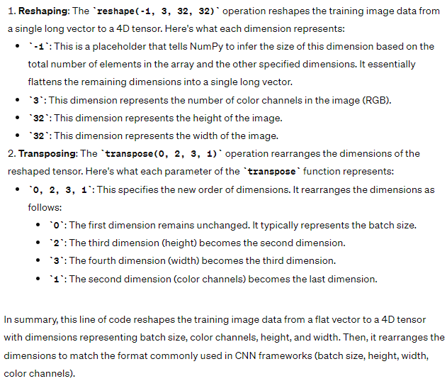

```python
train_dir
```

```
'C:/Users/gongl1/Desktop/Machine Learning - Bose/Assignment 6/extracted dataset folder/cifar-10-batches-py\\train'
```

```python
validation_dir
```

```
'C:/Users/gongl1/Desktop/Machine Learning - Bose/Assignment 6/extracted dataset folder/cifar-10-batches-py\\validation'
```

```python
# Use ImageDataGenerator to create data generators for train and validation sets with data augmentation
train_datagen = ImageDataGenerator(
    rescale=1./255,
    shear_range=0.2,
    zoom_range=0.2,
    horizontal_flip=True
)

validation_datagen = ImageDataGenerator(rescale=1./255)

train_generator = train_datagen.flow_from_directory(
    train_dir,
    target_size=(64, 64),
    batch_size=32,
    class_mode='categorical'
)

validation_generator = validation_datagen.flow_from_directory(
    validation_dir,
    target_size=(64, 64),
    batch_size=32,
    class_mode='categorical'
)
```

```
Found 40000 images belonging to 10 classes.
Found 10000 images belonging to 10 classes.
```

It uses the ImageDataGenerator class from Keras to perform data augmentation on the training data and preprocess the validation data.

1. train_datagen = ImageDataGenerator(...): This initializes an ImageDataGenerator object for the training data. The parameters inside the parentheses specify the types of data augmentation to be applied to the images. In this case: rescale=1./255: This rescales the pixel values of the images to the range [0, 1]. shear_range=0.2: This randomly applies shearing transformations to the images. zoom_range=0.2: This randomly applies zooming transformations to the images. horizontal_flip=True: This randomly flips images horizontally.
2. validation_datagen = ImageDataGenerator(rescale=1./255): This initializes an ImageDataGenerator object for the validation data. It only applies rescaling to the pixel values, without any data augmentation.
3. train_generator = train_datagen.flow_from_directory(...): This creates a generator for the training data. It loads images from the train_dir directory, resizes them to the specified target_size (in this case, (64, 64)), and preprocesses them using the transformations specified in train_datagen. The class_mode parameter is set to 'categorical', indicating that the labels are provided as categorical arrays.
4. validation_generator = validation_datagen.flow_from_directory(...): Similar to train_generator, this creates a generator for the validation data. It loads images from the validation_dir directory, resizes them, and preprocesses them using the transformations specified in validation_datagen. Overall, these generators are used to efficiently load and preprocess batches of images during model training and evaluation. They are essential for handling large datasets that cannot fit into memory all at once.

**batch_size=32: This parameter specifies the batch size, i.e., the number of images to include in each batch.**

```python
# Take a look at the training and validation sets
print("Image shape of each training observation:", train_generator.image_shape)
print("Total number of classes to predict on:", train_generator.num_classes)
```

```
Image shape of each training observation: (64, 64, 3)
Total number of classes to predict on: 10
```

# 2. Initial Classifier Build

```python
from keras.models import Sequential
from keras.layers import Conv2D, MaxPooling2D, Flatten, Dense
```

```python
# Initialize the CNN model
model = Sequential()

# Add the first convolutional layer
model.add(Conv2D(32, (3, 3), activation='relu', input_shape=(64, 64, 3)))

# Add a max pooling layer
model.add(MaxPooling2D(pool_size=(2, 2)))

# Add a second convolutional layer
model.add(Conv2D(64, (3, 3), activation='relu'))

# Add another max pooling layer
model.add(MaxPooling2D(pool_size=(2, 2)))

# Flatten the feature maps
model.add(Flatten())

# Add a fully connected layer
model.add(Dense(128, activation='relu'))

# Add the output layer
model.add(Dense(10, activation='softmax'))

# Compile the model
model.compile(optimizer='adam', loss='categorical_crossentropy', metrics=['accuracy'])

# Print a summary of the model architecture
model.summary()
```

```
Model: "sequential"
```

```
┏━━━━━━━━━━━━━━━━━━━━━━━━━━━━━━━━━━━━━━┳━━━━━━━━━━━━━━━━━━━━━━━━━━━━━┳━━━━━━━━━━━━━━━━━┓
┃ Layer (type)                         ┃ Output Shape                ┃         Param # ┃
┡━━━━━━━━━━━━━━━━━━━━━━━━━━━━━━━━━━━━━━╇━━━━━━━━━━━━━━━━━━━━━━━━━━━━━╇━━━━━━━━━━━━━━━━━┩
│ conv2d (Conv2D)                      │ (None, 62, 62, 32)          │             896 │
├──────────────────────────────────────┼─────────────────────────────┼─────────────────┤
│ max_pooling2d (MaxPooling2D)         │ (None, 31, 31, 32)          │               0 │
├──────────────────────────────────────┼─────────────────────────────┼─────────────────┤
│ conv2d_1 (Conv2D)                    │ (None, 29, 29, 64)          │          18,496 │
├──────────────────────────────────────┼─────────────────────────────┼─────────────────┤
│ max_pooling2d_1 (MaxPooling2D)       │ (None, 14, 14, 64)          │               0 │
├──────────────────────────────────────┼─────────────────────────────┼─────────────────┤
│ flatten (Flatten)                    │ (None, 12544)               │               0 │
├──────────────────────────────────────┼─────────────────────────────┼─────────────────┤
│ dense (Dense)                        │ (None, 128)                 │       1,605,760 │
├──────────────────────────────────────┼─────────────────────────────┼─────────────────┤
│ dense_1 (Dense)                      │ (None, 10)                  │           1,290 │
└──────────────────────────────────────┴─────────────────────────────┴─────────────────┘
```

```
 Total params: 1,626,442 (6.20 MB)
```

```
 Trainable params: 1,626,442 (6.20 MB)
```

```
 Non-trainable params: 0 (0.00 B)
```

# 3. Model Runs

```python
from keras.callbacks import ModelCheckpoint
```

```python
# Define the combinations of steps_per_epoch and epochs
combinations = [
    (100, 2), (250, 2), (500, 2),
    (100, 5), (250, 5), (500, 5),
    (100, 9), (250, 9), (500, 9),
    (5, 10)
]

# (100, 2) means that during each epoch of training, the model will iterate over 100 batches of data drawn from the generator, and this process will be repeated for 2 epochs.
# By varying these parameters, you can control how much data the model sees in each epoch (steps_per_epoch) and how many times the model goes through the entire dataset (epochs). This flexibility allows you to experiment with different training strategies and find the optimal combination for your specific dataset and model architecture.
```

The batch_size is set to 32 (batch_size=32), it means that each batch will contain 32 data points.

Therefore, in the combination (100, 2), if the batch_size is 32, during each epoch of training, the model will iterate over 100 batches of 32 data points, and this process will be repeated for 2 epochs.

```python
# Initialize an empty list to store accuracy for each combination
accuracy_list = []
```

```python
# Need to create test_generator first
```

```python
dataset_dir
```

```
'C:/Users/gongl1/Desktop/Machine Learning - Bose/Assignment 6/extracted dataset folder/cifar-10-batches-py'
```

```python
# Define the directory for the test set
test_dir = os.path.join(dataset_dir, 'test')

# Create the test directory if it doesn't exist
if not os.path.exists(test_dir):
    os.makedirs(test_dir)

# Load the CIFAR-10 test data batch
test_batch_file = os.path.join(dataset_dir, 'test_batch')
test_batch = unpickle(test_batch_file)
test_images = test_batch[b'data'].reshape(-1, 3, 32, 32).transpose(0, 2, 3, 1)
test_labels = np.array(test_batch[b'labels'])

# Save test images to the test directory
for i in range(len(test_images)):
    image_path = os.path.join(test_dir, f'class_{test_labels[i]}', f'image_{i}.png')
    os.makedirs(os.path.dirname(image_path), exist_ok=True)
    plt.imsave(image_path, test_images[i])

# Use ImageDataGenerator to create a data generator for the test set
test_datagen = ImageDataGenerator(rescale=1./255)
# It ensures that the test_datagen only applies rescaling to the test images and doesn't include any data augmentation techniques like shear, zoom, or horizontal flip.

test_generator = test_datagen.flow_from_directory(
    test_dir,
    target_size=(64, 64),
    batch_size=32,
    class_mode='categorical'
)
```

```
Found 10000 images belonging to 10 classes.
```

```python
# For the first run, use the following parameters:

# epochs = 30
# steps_per_epoch = 625
```

```
625/625 ━━━━━━━━━━━━━━━━━━━━ 53s 82ms/step - accuracy: 0.3267 - loss: 1.8315 - val_accuracy: 0.5038 - val_loss: 1.3889
625/625 ━━━━━━━━━━━━━━━━━━━━ 49s 78ms/step - accuracy: 0.5198 - loss: 1.3688 - val_accuracy: 0.5540 - val_loss: 1.2524
```

```
625/625 ━━━━━━━━━━━━━━━━━━━━ 6s 9ms/step - accuracy: 0.0000e+00 - loss: 0.0000e+00 - val_accuracy: 0.5540 - val_loss: 1.2524
625/625 ━━━━━━━━━━━━━━━━━━━━ 52s 83ms/step - accuracy: 0.5587 - loss: 1.2463 - val_accuracy: 0.5887 - val_loss: 1.1513
625/625 ━━━━━━━━━━━━━━━━━━━━ 52s 84ms/step - accuracy: 0.5931 - loss: 1.1522 - val_accuracy: 0.6164 - val_loss: 1.0881
625/625 ━━━━━━━━━━━━━━━━━━━━ 6s 9ms/step - accuracy: 0.0000e+00 - loss: 0.0000e+00 - val_accuracy: 0.6164 - val_loss: 1.0881
625/625 ━━━━━━━━━━━━━━━━━━━━ 49s 78ms/step - accuracy: 0.6203 - loss: 1.0941 - val_accuracy: 0.6399 - val_loss: 1.0273
625/625 ━━━━━━━━━━━━━━━━━━━━ 48s 76ms/step - accuracy: 0.6381 - loss: 1.0365 - val_accuracy: 0.6495 - val_loss: 1.0175
625/625 ━━━━━━━━━━━━━━━━━━━━ 6s 9ms/step - accuracy: 0.0000e+00 - loss: 0.0000e+00 - val_accuracy: 0.6495 - val_loss: 1.0175
625/625 ━━━━━━━━━━━━━━━━━━━━ 48s 77ms/step - accuracy: 0.6621 - loss: 0.9723 - val_accuracy: 0.6666 - val_loss: 0.9707
625/625 ━━━━━━━━━━━━━━━━━━━━ 47s 76ms/step - accuracy: 0.6681 - loss: 0.9423 - val_accuracy: 0.6658 - val_loss: 0.9568
625/625 ━━━━━━━━━━━━━━━━━━━━ 6s 9ms/step - accuracy: 0.0000e+00 - loss: 0.0000e+00 - val_accuracy: 0.6658 - val_loss: 0.9568
625/625 ━━━━━━━━━━━━━━━━━━━━ 48s 77ms/step - accuracy: 0.6850 - loss: 0.9168 - val_accuracy: 0.6718 - val_loss: 0.9541
625/625 ━━━━━━━━━━━━━━━━━━━━ 48s 76ms/step - accuracy: 0.6884 - loss: 0.9058 - val_accuracy: 0.6798 - val_loss: 0.9230
625/625 ━━━━━━━━━━━━━━━━━━━━ 6s 9ms/step - accuracy: 0.0000e+00 - loss: 0.0000e+00 - val_accuracy: 0.6798 - val_loss: 0.9230
625/625 ━━━━━━━━━━━━━━━━━━━━ 48s 77ms/step - accuracy: 0.6982 - loss: 0.8680 - val_accuracy: 0.6962 - val_loss: 0.8884
625/625 ━━━━━━━━━━━━━━━━━━━━ 48s 77ms/step - accuracy: 0.7047 - loss: 0.8584 - val_accuracy: 0.6976 - val_loss: 0.8786
625/625 ━━━━━━━━━━━━━━━━━━━━ 6s 9ms/step - accuracy: 0.0000e+00 - loss: 0.0000e+00 - val_accuracy: 0.6976 - val_loss: 0.8786
625/625 ━━━━━━━━━━━━━━━━━━━━ 49s 77ms/step - accuracy: 0.7125 - loss: 0.8300 - val_accuracy: 0.6770 - val_loss: 0.9393
625/625 ━━━━━━━━━━━━━━━━━━━━ 48s 77ms/step - accuracy: 0.7255 - loss: 0.7958 - val_accuracy: 0.7016 - val_loss: 0.8753
625/625 ━━━━━━━━━━━━━━━━━━━━ 6s 9ms/step - accuracy: 0.0000e+00 - loss: 0.0000e+00 - val_accuracy: 0.7016 - val_loss: 0.8753
625/625 ━━━━━━━━━━━━━━━━━━━━ 49s 79ms/step - accuracy: 0.7181 - loss: 0.8041 - val_accuracy: 0.7077 - val_loss: 0.8589
625/625 ━━━━━━━━━━━━━━━━━━━━ 48s 77ms/step - accuracy: 0.7275 - loss: 0.7807 - val_accuracy: 0.6966 - val_loss: 0.9047
625/625 ━━━━━━━━━━━━━━━━━━━━ 6s 9ms/step - accuracy: 0.0000e+00 - loss: 0.0000e+00 - val_accuracy: 0.6966 - val_loss: 0.9047
625/625 ━━━━━━━━━━━━━━━━━━━━ 49s 79ms/step - accuracy: 0.7425 - loss: 0.7496 - val_accuracy: 0.7029 - val_loss: 0.8907
625/625 ━━━━━━━━━━━━━━━━━━━━ 71s 113ms/step - accuracy: 0.7421 - loss: 0.7533 - val_accuracy: 0.7087 - val_loss: 0.8579
625/625 ━━━━━━━━━━━━━━━━━━━━ 9s 14ms/step - accuracy: 0.0000e+00 - loss: 0.0000e+00 - val_accuracy: 0.7087 - val_loss: 0.8579
625/625 ━━━━━━━━━━━━━━━━━━━━ 64s 101ms/step - accuracy: 0.7443 - loss: 0.7344 - val_accuracy: 0.7083 - val_loss: 0.8939
625/625 ━━━━━━━━━━━━━━━━━━━━ 49s 79ms/step - accuracy: 0.7517 - loss: 0.7216 - val_accuracy: 0.7159 - val_loss: 0.8539
625/625 ━━━━━━━━━━━━━━━━━━━━ 6s 9ms/step - accuracy: 0.0000e+00 - loss: 0.0000e+00 - val_accuracy: 0.7159 - val_loss: 0.8539
```

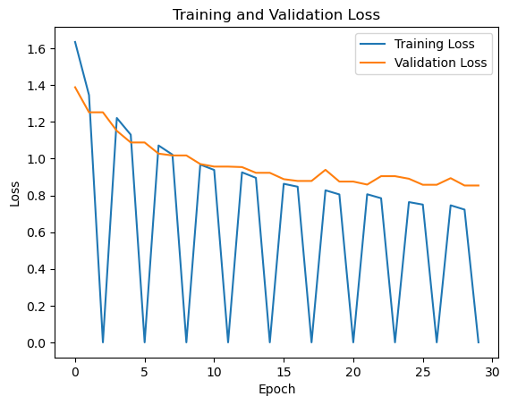

```
WARNING:absl:You are saving your model as an HDF5 file via `model.save()` or `keras.saving.save_model(model)`. This file format is considered legacy. We recommend using instead the native Keras format, e.g. `model.save('my_model.keras')` or `keras.saving.save_model(model, 'my_model.keras')`.
```

```
313/313 ━━━━━━━━━━━━━━━━━━━━ 6s 19ms/step - accuracy: 0.7119 - loss: 0.8549
Test Loss: 0.8589862585067749
Test Accuracy: 0.710099995136261
```

```python
# a) Train the model
history = model.fit(
    train_generator,
    epochs=30,
    steps_per_epoch=625,
    validation_data=validation_generator
)

# b) Plot the training and validation loss curves
import matplotlib.pyplot as plt

plt.plot(history.history['loss'], label='Training Loss')
plt.plot(history.history['val_loss'], label='Validation Loss')
plt.xlabel('Epoch')
plt.ylabel('Loss')
plt.title('Training and Validation Loss')
plt.legend()
plt.savefig('loss_plot.png')
plt.show()

# c) Save the model to a file
model.save('my_model.h5')

# d) Predict using the saved model and the test dataset
test_loss, test_accuracy = model.evaluate(test_generator)
print('Test Loss:', test_loss)
print('Test Accuracy:', test_accuracy)
```

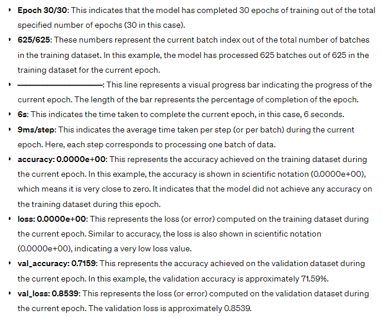

```python
# why accuracy: 0.0000e+00 while loss: 0.0000e+00? a very low accuracy with a low loss?
```

```
100/100 ━━━━━━━━━━━━━━━━━━━━ 13s 127ms/step - accuracy: 0.7542 - loss: 0.6814 - val_accuracy: 0.7085 - val_loss: 0.8865
100/100 ━━━━━━━━━━━━━━━━━━━━ 13s 126ms/step - accuracy: 0.7612 - loss: 0.6672 - val_accuracy: 0.7158 - val_loss: 0.8502
```

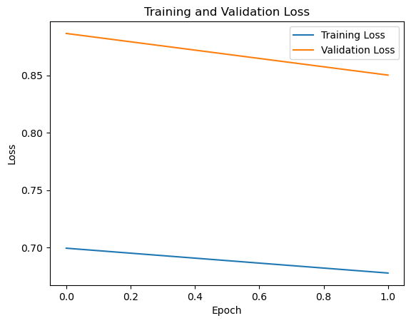

```
313/313 ━━━━━━━━━━━━━━━━━━━━ 6s 20ms/step - accuracy: 0.7210 - loss: 0.8439
250/250 ━━━━━━━━━━━━━━━━━━━━ 23s 91ms/step - accuracy: 0.7528 - loss: 0.7046 - val_accuracy: 0.7146 - val_loss: 0.8856
250/250 ━━━━━━━━━━━━━━━━━━━━ 22s 89ms/step - accuracy: 0.7559 - loss: 0.6994 - val_accuracy: 0.7183 - val_loss: 0.8517
```

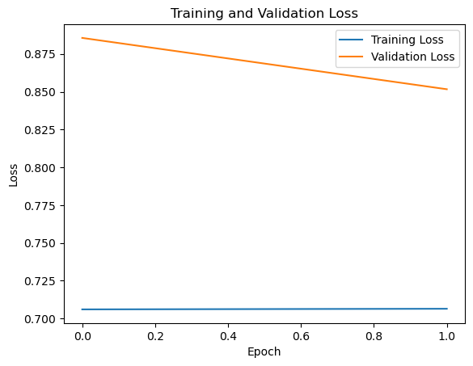

```
313/313 ━━━━━━━━━━━━━━━━━━━━ 6s 19ms/step - accuracy: 0.7171 - loss: 0.8690
500/500 ━━━━━━━━━━━━━━━━━━━━ 40s 79ms/step - accuracy: 0.7610 - loss: 0.6871 - val_accuracy: 0.7044 - val_loss: 0.9083
500/500 ━━━━━━━━━━━━━━━━━━━━ 39s 79ms/step - accuracy: 0.7581 - loss: 0.6914 - val_accuracy: 0.7216 - val_loss: 0.8398
```

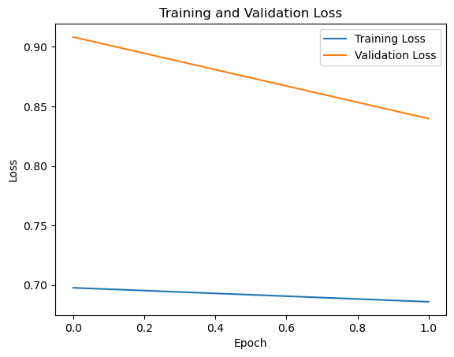

```
313/313 ━━━━━━━━━━━━━━━━━━━━ 6s 19ms/step - accuracy: 0.7263 - loss: 0.8295
100/100 ━━━━━━━━━━━━━━━━━━━━ 13s 123ms/step - accuracy: 0.7963 - loss: 0.6211 - val_accuracy: 0.7225 - val_loss: 0.8597
100/100 ━━━━━━━━━━━━━━━━━━━━ 12s 124ms/step - accuracy: 0.7519 - loss: 0.7219 - val_accuracy: 0.7240 - val_loss: 0.8582
100/100 ━━━━━━━━━━━━━━━━━━━━ 12s 125ms/step - accuracy: 0.7733 - loss: 0.6480 - val_accuracy: 0.7064 - val_loss: 0.8934
100/100 ━━━━━━━━━━━━━━━━━━━━ 12s 125ms/step - accuracy: 0.7644 - loss: 0.6909 - val_accuracy: 0.7200 - val_loss: 0.8837
100/100 ━━━━━━━━━━━━━━━━━━━━ 12s 121ms/step - accuracy: 0.7544 - loss: 0.6953 - val_accuracy: 0.7207 - val_loss: 0.8538
```

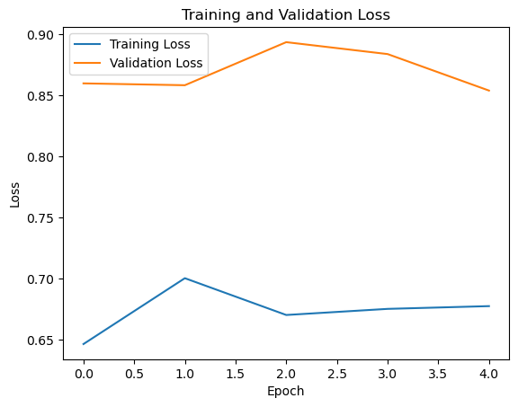

```
313/313 ━━━━━━━━━━━━━━━━━━━━ 6s 19ms/step - accuracy: 0.7264 - loss: 0.8382
250/250 ━━━━━━━━━━━━━━━━━━━━ 22s 87ms/step - accuracy: 0.7669 - loss: 0.6749 - val_accuracy: 0.7202 - val_loss: 0.8623
250/250 ━━━━━━━━━━━━━━━━━━━━ 22s 88ms/step - accuracy: 0.7711 - loss: 0.6637 - val_accuracy: 0.7176 - val_loss: 0.8591
250/250 ━━━━━━━━━━━━━━━━━━━━ 22s 87ms/step - accuracy: 0.7595 - loss: 0.6821 - val_accuracy: 0.7177 - val_loss: 0.8801
250/250 ━━━━━━━━━━━━━━━━━━━━ 22s 88ms/step - accuracy: 0.7574 - loss: 0.6912 - val_accuracy: 0.7186 - val_loss: 0.8635
250/250 ━━━━━━━━━━━━━━━━━━━━ 21s 85ms/step - accuracy: 0.7793 - loss: 0.6321 - val_accuracy: 0.7064 - val_loss: 0.9097
```

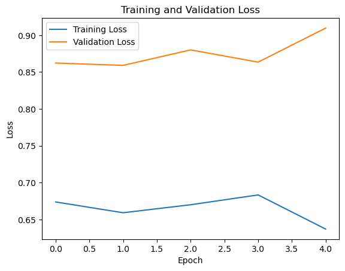

```
313/313 ━━━━━━━━━━━━━━━━━━━━ 7s 21ms/step - accuracy: 0.7123 - loss: 0.9053
500/500 ━━━━━━━━━━━━━━━━━━━━ 40s 79ms/step - accuracy: 0.7760 - loss: 0.6438 - val_accuracy: 0.7186 - val_loss: 0.8579
500/500 ━━━━━━━━━━━━━━━━━━━━ 39s 79ms/step - accuracy: 0.7803 - loss: 0.6324 - val_accuracy: 0.7029 - val_loss: 0.9114
249/500 ━━━━━━━━━━━━━━━━━━━━ 16s 67ms/step - accuracy: 0.7711 - loss: 0.6596
```

```
500/500 ━━━━━━━━━━━━━━━━━━━━ 22s 44ms/step - accuracy: 0.7715 - loss: 0.6562 - val_accuracy: 0.7073 - val_loss: 0.8972
500/500 ━━━━━━━━━━━━━━━━━━━━ 38s 76ms/step - accuracy: 0.7755 - loss: 0.6351 - val_accuracy: 0.7321 - val_loss: 0.8231
500/500 ━━━━━━━━━━━━━━━━━━━━ 38s 76ms/step - accuracy: 0.7893 - loss: 0.6092 - val_accuracy: 0.7264 - val_loss: 0.8412
```

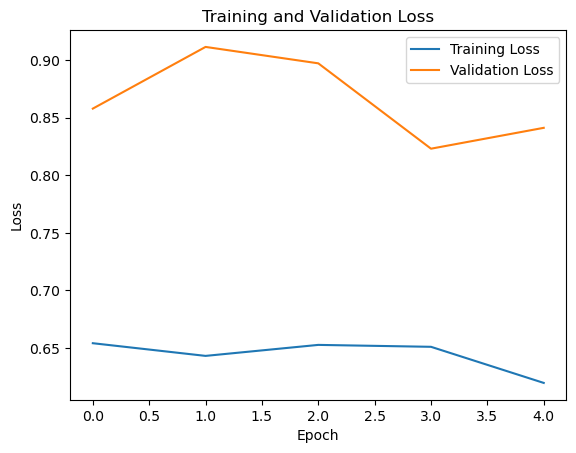

```
313/313 ━━━━━━━━━━━━━━━━━━━━ 6s 18ms/step - accuracy: 0.7248 - loss: 0.8472
100/100 ━━━━━━━━━━━━━━━━━━━━ 12s 122ms/step - accuracy: 0.7858 - loss: 0.6100 - val_accuracy: 0.7231 - val_loss: 0.8553
100/100 ━━━━━━━━━━━━━━━━━━━━ 12s 122ms/step - accuracy: 0.7858 - loss: 0.5999 - val_accuracy: 0.7254 - val_loss: 0.8333
100/100 ━━━━━━━━━━━━━━━━━━━━ 12s 120ms/step - accuracy: 0.7892 - loss: 0.5967 - val_accuracy: 0.7190 - val_loss: 0.8745
100/100 ━━━━━━━━━━━━━━━━━━━━ 12s 119ms/step - accuracy: 0.8098 - loss: 0.5634 - val_accuracy: 0.7155 - val_loss: 0.8975
100/100 ━━━━━━━━━━━━━━━━━━━━ 12s 118ms/step - accuracy: 0.7813 - loss: 0.6142 - val_accuracy: 0.7302 - val_loss: 0.8394
100/100 ━━━━━━━━━━━━━━━━━━━━ 12s 116ms/step - accuracy: 0.7963 - loss: 0.5827 - val_accuracy: 0.7270 - val_loss: 0.8661
100/100 ━━━━━━━━━━━━━━━━━━━━ 10s 106ms/step - accuracy: 0.7968 - loss: 0.5663 - val_accuracy: 0.7248 - val_loss: 0.8464
100/100 ━━━━━━━━━━━━━━━━━━━━ 9s 95ms/step - accuracy: 0.7899 - loss: 0.6014 - val_accuracy: 0.7233 - val_loss: 0.9044
100/100 ━━━━━━━━━━━━━━━━━━━━ 9s 95ms/step - accuracy: 0.7843 - loss: 0.6462 - val_accuracy: 0.7182 - val_loss: 0.8772
```

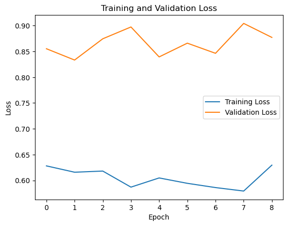

```
313/313 ━━━━━━━━━━━━━━━━━━━━ 6s 19ms/step - accuracy: 0.7173 - loss: 0.8847
250/250 ━━━━━━━━━━━━━━━━━━━━ 22s 87ms/step - accuracy: 0.7831 - loss: 0.6142 - val_accuracy: 0.7260 - val_loss: 0.8879
250/250 ━━━━━━━━━━━━━━━━━━━━ 22s 87ms/step - accuracy: 0.7890 - loss: 0.6078 - val_accuracy: 0.6990 - val_loss: 1.0100
250/250 ━━━━━━━━━━━━━━━━━━━━ 22s 87ms/step - accuracy: 0.7892 - loss: 0.6216 - val_accuracy: 0.7289 - val_loss: 0.8436
250/250 ━━━━━━━━━━━━━━━━━━━━ 24s 95ms/step - accuracy: 0.7912 - loss: 0.6020 - val_accuracy: 0.7201 - val_loss: 0.8787
250/250 ━━━━━━━━━━━━━━━━━━━━ 23s 93ms/step - accuracy: 0.7906 - loss: 0.5969 - val_accuracy: 0.7225 - val_loss: 0.8571
250/250 ━━━━━━━━━━━━━━━━━━━━ 6s 23ms/step - accuracy: 0.0000e+00 - loss: 0.0000e+00 - val_accuracy: 0.7225 - val_loss: 0.8571
250/250 ━━━━━━━━━━━━━━━━━━━━ 22s 88ms/step - accuracy: 0.7893 - loss: 0.6091 - val_accuracy: 0.7217 - val_loss: 0.8794
250/250 ━━━━━━━━━━━━━━━━━━━━ 22s 87ms/step - accuracy: 0.7900 - loss: 0.6138 - val_accuracy: 0.7199 - val_loss: 0.8959
250/250 ━━━━━━━━━━━━━━━━━━━━ 22s 87ms/step - accuracy: 0.7830 - loss: 0.6062 - val_accuracy: 0.7146 - val_loss: 0.9242
```

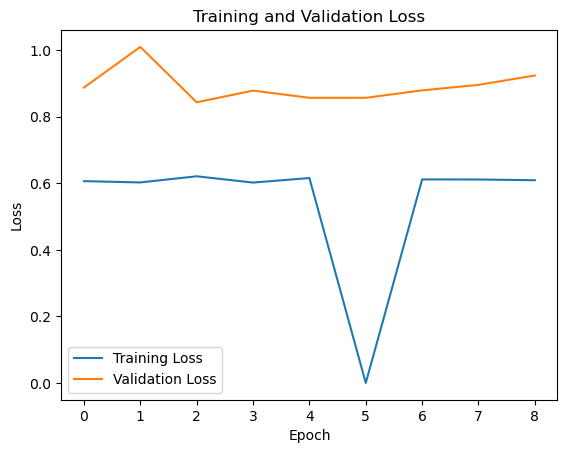

```
313/313 ━━━━━━━━━━━━━━━━━━━━ 6s 19ms/step - accuracy: 0.7098 - loss: 0.9502
500/500 ━━━━━━━━━━━━━━━━━━━━ 38s 75ms/step - accuracy: 0.7860 - loss: 0.5945 - val_accuracy: 0.7218 - val_loss: 0.8750
500/500 ━━━━━━━━━━━━━━━━━━━━ 38s 76ms/step - accuracy: 0.8010 - loss: 0.5750 - val_accuracy: 0.7324 - val_loss: 0.8482
500/500 ━━━━━━━━━━━━━━━━━━━━ 23s 47ms/step - accuracy: 0.7958 - loss: 0.5799 - val_accuracy: 0.7305 - val_loss: 0.8518
500/500 ━━━━━━━━━━━━━━━━━━━━ 39s 78ms/step - accuracy: 0.7999 - loss: 0.5615 - val_accuracy: 0.7182 - val_loss: 0.9248
500/500 ━━━━━━━━━━━━━━━━━━━━ 38s 76ms/step - accuracy: 0.7993 - loss: 0.5794 - val_accuracy: 0.7128 - val_loss: 0.9147
500/500 ━━━━━━━━━━━━━━━━━━━━ 21s 43ms/step - accuracy: 0.7994 - loss: 0.5753 - val_accuracy: 0.7130 - val_loss: 0.9294
500/500 ━━━━━━━━━━━━━━━━━━━━ 38s 76ms/step - accuracy: 0.8052 - loss: 0.5726 - val_accuracy: 0.7224 - val_loss: 0.8956
500/500 ━━━━━━━━━━━━━━━━━━━━ 38s 76ms/step - accuracy: 0.8028 - loss: 0.5512 - val_accuracy: 0.7209 - val_loss: 0.8805
500/500 ━━━━━━━━━━━━━━━━━━━━ 21s 43ms/step - accuracy: 0.8113 - loss: 0.5395 - val_accuracy: 0.7238 - val_loss: 0.8634
```

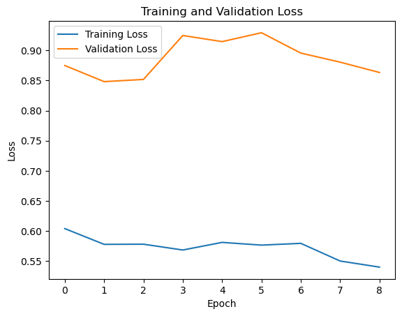

```
313/313 ━━━━━━━━━━━━━━━━━━━━ 7s 21ms/step - accuracy: 0.7305 - loss: 0.8822
5/5 ━━━━━━━━━━━━━━━━━━━━ 6s 2s/step - accuracy: 0.7494 - loss: 0.7063 - val_accuracy: 0.7244 - val_loss: 0.8777
5/5 ━━━━━━━━━━━━━━━━━━━━ 6s 1s/step - accuracy: 0.8036 - loss: 0.5494 - val_accuracy: 0.7165 - val_loss: 0.9032
5/5 ━━━━━━━━━━━━━━━━━━━━ 6s 1s/step - accuracy: 0.8039 - loss: 0.6255 - val_accuracy: 0.7142 - val_loss: 0.8979
5/5 ━━━━━━━━━━━━━━━━━━━━ 6s 1s/step - accuracy: 0.8301 - loss: 0.4932 - val_accuracy: 0.7102 - val_loss: 0.9356
5/5 ━━━━━━━━━━━━━━━━━━━━ 6s 1s/step - accuracy: 0.7596 - loss: 0.6375 - val_accuracy: 0.7226 - val_loss: 0.8802
5/5 ━━━━━━━━━━━━━━━━━━━━ 6s 1s/step - accuracy: 0.8100 - loss: 0.5604 - val_accuracy: 0.7269 - val_loss: 0.8611
5/5 ━━━━━━━━━━━━━━━━━━━━ 6s 1s/step - accuracy: 0.8344 - loss: 0.4321 - val_accuracy: 0.7255 - val_loss: 0.8677
5/5 ━━━━━━━━━━━━━━━━━━━━ 6s 1s/step - accuracy: 0.8149 - loss: 0.6040 - val_accuracy: 0.7207 - val_loss: 0.8898
5/5 ━━━━━━━━━━━━━━━━━━━━ 6s 1s/step - accuracy: 0.8077 - loss: 0.6300 - val_accuracy: 0.7178 - val_loss: 0.9114
5/5 ━━━━━━━━━━━━━━━━━━━━ 6s 1s/step - accuracy: 0.7656 - loss: 0.6977 - val_accuracy: 0.7257 - val_loss: 0.8912
```

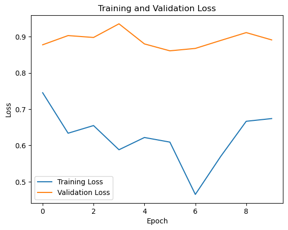

```
313/313 ━━━━━━━━━━━━━━━━━━━━ 6s 18ms/step - accuracy: 0.7282 - loss: 0.8821
Final Accuracy Results:
   Steps per Epoch  Epochs  Accuracy
0              100       2    0.7154
1              250       2    0.7148
2              500       2    0.7201
3              100       5    0.7213
4              250       5    0.7071
5              500       5    0.7222
6              100       9    0.7166
7              250       9    0.7099
8              500       9    0.7270
9                5      10    0.7205
```

```python
import pandas as pd
import matplotlib.pyplot as plt

# Define a function to train and evaluate the model for a given combination of parameters
def train_and_evaluate(steps_per_epoch, epochs):
    # Train the model using fit() with the specified parameters
    history = model.fit(
        train_generator,
        steps_per_epoch=steps_per_epoch,
        epochs=epochs,
        validation_data=validation_generator,
        verbose=1
    )

    # Plot training and validation loss
    plt.plot(history.history['loss'], label='Training Loss')
    plt.plot(history.history['val_loss'], label='Validation Loss')
    plt.xlabel('Epoch')
    plt.ylabel('Loss')
    plt.title('Training and Validation Loss')
    plt.legend()
    plt.savefig(f'training_validation_loss_{steps_per_epoch}_{epochs}.png')
    plt.show()

    # Save the trained model to a file in native Keras format
    model.save(f'model_{steps_per_epoch}_{epochs}.keras')

    # Predict using the saved model on the test dataset
    test_loss, test_accuracy = model.evaluate(test_generator)

    return test_accuracy




# Define the parameter combinations
parameter_combinations = [
    (100, 2), (250, 2), (500, 2),
    (100, 5), (250, 5), (500, 5),
    (100, 9), (250, 9), (500, 9),
    (5, 10)
]

# Create an empty list to store accuracy results
accuracy_results = []




# Loop through each parameter combination
for steps_per_epoch, epochs in parameter_combinations:
    # Train and evaluate the model for the current combination
    accuracy = train_and_evaluate(steps_per_epoch, epochs)

    # Append the accuracy results to the list
    accuracy_results.append({'Steps per Epoch': steps_per_epoch,
                             'Epochs': epochs,
                             'Accuracy': accuracy})

# Create a dataframe from the accuracy results list
accuracy_df = pd.DataFrame(accuracy_results)

# Display the final dataframe
print("Final Accuracy Results:")
print(accuracy_df)
```

# 4. Model Run with early stopping

```
1250/1250 ━━━━━━━━━━━━━━━━━━━━ 92s 73ms/step - accuracy: 0.8088 - loss: 0.5538 - val_accuracy: 0.7234 - val_loss: 0.8680
1250/1250 ━━━━━━━━━━━━━━━━━━━━ 91s 72ms/step - accuracy: 0.8124 - loss: 0.5394 - val_accuracy: 0.7253 - val_loss: 0.8714
1250/1250 ━━━━━━━━━━━━━━━━━━━━ 90s 72ms/step - accuracy: 0.8129 - loss: 0.5333 - val_accuracy: 0.7271 - val_loss: 0.8870
1250/1250 ━━━━━━━━━━━━━━━━━━━━ 91s 72ms/step - accuracy: 0.8176 - loss: 0.5163 - val_accuracy: 0.7226 - val_loss: 0.9083
```

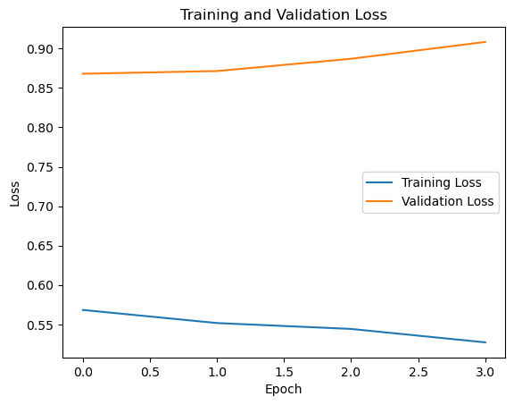

```
313/313 ━━━━━━━━━━━━━━━━━━━━ 6s 19ms/step - accuracy: 0.7132 - loss: 0.9469
Test Accuracy with Early Stopping: 0.7250000238418579
```

```python
import pandas as pd
import matplotlib.pyplot as plt
from keras.callbacks import EarlyStopping

# Define the EarlyStopping callback
early_stopping = EarlyStopping(monitor='val_loss', patience=3)

# Train the model using fit() with the EarlyStopping callback
history = model.fit(
    train_generator,
    epochs=500,  # Assuming maximum epochs of 500
    validation_data=validation_generator,
    callbacks=[early_stopping],
    verbose=1
)

# Plot training and validation loss
plt.plot(history.history['loss'], label='Training Loss')
plt.plot(history.history['val_loss'], label='Validation Loss')
plt.xlabel('Epoch')
plt.ylabel('Loss')
plt.title('Training and Validation Loss')
plt.legend()
plt.savefig('training_validation_loss_early_stopping.png')
plt.show()

# Save the trained model to a file in native Keras format
model.save('model_early_stopping.keras')

# Predict using the early-stopped model on the test dataset
test_loss, test_accuracy = model.evaluate(test_generator)
print("Test Accuracy with Early Stopping:", test_accuracy)
```

```
1250/1250 ━━━━━━━━━━━━━━━━━━━━ 92s 73ms/step - accuracy: 0.8224 - loss: 0.5080 - val_accuracy: 0.7273 - val_loss: 0.8805
1250/1250 ━━━━━━━━━━━━━━━━━━━━ 92s 73ms/step - accuracy: 0.8223 - loss: 0.4981 - val_accuracy: 0.7271 - val_loss: 0.8940
1250/1250 ━━━━━━━━━━━━━━━━━━━━ 97s 77ms/step - accuracy: 0.8274 - loss: 0.4889 - val_accuracy: 0.7209 - val_loss: 0.9387
1250/1250 ━━━━━━━━━━━━━━━━━━━━ 110s 88ms/step - accuracy: 0.8297 - loss: 0.4751 - val_accuracy: 0.7281 - val_loss: 0.9133
```

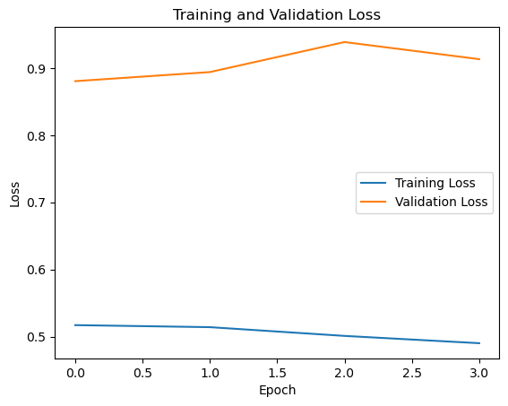

```
313/313 ━━━━━━━━━━━━━━━━━━━━ 9s 29ms/step - accuracy: 0.7275 - loss: 0.9418
Test Accuracy with Early Stopping: 0.7311999797821045
```

```python
import pandas as pd
import matplotlib.pyplot as plt
from keras.callbacks import EarlyStopping

# Define the EarlyStopping callback
early_stopping = EarlyStopping(monitor='val_loss', patience=3)

# Train the model using fit() with the EarlyStopping callback
history = model.fit(
    train_generator,
    epochs=100,  # Assuming maximum epochs of 100
    validation_data=validation_generator,
    callbacks=[early_stopping],
    verbose=1
)

# Plot training and validation loss
plt.plot(history.history['loss'], label='Training Loss')
plt.plot(history.history['val_loss'], label='Validation Loss')
plt.xlabel('Epoch')
plt.ylabel('Loss')
plt.title('Training and Validation Loss')
plt.legend()
plt.savefig('training_validation_loss_early_stopping.png')
plt.show()

# Save the trained model to a file in native Keras format
model.save('model_early_stopping100.keras')

# Predict using the early-stopped model on the test dataset
test_loss, test_accuracy = model.evaluate(test_generator)
print("Test Accuracy with Early Stopping:", test_accuracy)
```

Training Loss Curve: This curve shows the value of the loss function (e.g., cross-entropy loss) on the training dataset at each epoch during the training process. It represents how well the model is fitting the training data over time. A decreasing training loss indicates that the model is learning to minimize the difference between the predicted and actual labels on the training set.

Validation Loss Curve: This curve shows the value of the loss function on the validation dataset at each epoch during training. It measures the generalization performance of the model on unseen data. An increasing validation loss (or a gap between training and validation loss) may indicate overfitting, where the model is learning to memorize the training data rather than capturing underlying patterns.

By plotting these curves together, you can gain insights into the training process and identify potential issues such as overfitting or underfitting. Ideally, both the training and validation loss curves should decrease smoothly over time, indicating that the model is learning effectively without overfitting. However, if the validation loss starts to increase while the training loss continues to decrease, it suggests that the model may be overfitting to the training data.

# Out of all the runs, which model has the highest test data accuracy?

# Model with early stopping callback with a patience = 3 and 100 epochs has highest test data accuracy.

# 5. Discuss the effect of the following on accuracy and loss (train & test):

# Increasing the steps_per_epoch

# Increasing the number of epochs

Increasing the steps_per_epoch:

Effect on Training:

Accuracy: Increasing steps_per_epoch may lead to better utilization of the training data during each epoch, allowing the model to see more diverse samples. This could potentially improve training accuracy as the model receives more updates per epoch. Loss: With more steps per epoch, the model gets trained on more batches of data, which could lead to faster convergence and lower training loss.

Effect on Test: Accuracy: Increased steps_per_epoch in training might lead to better generalization if the model sees a more diverse set of examples during training. This could result in improved test accuracy.

Loss: Lower training loss might indicate better convergence, which may translate to lower test loss if the model generalizes well.

Increasing the number of epochs:

Effect on Training:

Accuracy: Initially, increasing epochs may improve training accuracy as the model gets more opportunities to learn from the data. However, training accuracy may plateau or even degrade over time due to overfitting, especially if the model is too complex or the dataset is limited.

Loss: Initially, training loss may decrease as the model learns more from the data. However, if the model starts to overfit, training loss may increase as the model memorizes noise in the training data.

Effect on Test:

Accuracy: Initially, increasing epochs may improve test accuracy as the model learns more from the training data. However, if overfitting occurs, test accuracy may degrade as the model fails to generalize well to unseen data.

Loss: Initially, test loss may decrease as the model learns more from the training data. However, if overfitting occurs, test loss may increase as the model fails to generalize well to unseen data.

In summary, increasing steps_per_epoch can help the model to see more diverse samples during training, potentially improving both training and test accuracy, as well as reducing both training and test loss. On the other hand, increasing the number of epochs can initially improve both accuracy and loss metrics, but may lead to overfitting if not controlled properly. Regularization techniques like early stopping can be used to mitigate overfitting when increasing the number of epochs.

# 6. Name two uses of zero padding in CNN.

Zero padding in convolutional neural networks (CNNs) serves several important purposes:

Preserving Spatial Dimensions:

Zero padding helps **preserve the spatial dimensions of the input volume through convolutional layers**. Without padding, the spatial dimensions reduce after each convolution operation, leading to a shrinking feature map. Padding allows the output feature map to have the same spatial dimensions as the input, which can be crucial for maintaining spatial information, especially in deeper layers of the network.

Avoiding Border Effects and Information Loss:

When performing convolution operations, pixels at the border of the input feature map are not covered by the filter entirely, resulting in information loss. **Zero padding addresses this issue by adding zeros around the input feature map, ensuring that all pixels are covered by the filter**. This helps to avoid border effects and ensures that all parts of the input contribute equally to the output.

In summary, zero padding in CNNs is used to preserve spatial dimensions and avoid border effects, ensuring that important spatial information is retained throughout the network's layers.

# 7. What is the use of a 1 x 1 kernel in CNN?

Dimensionality Reduction: A 1x1 kernel **reduces the number of channels in feature maps**, aiding computation and controlling overfitting.

Non-linear Transformation: Despite its small size, a 1x1 convolution applies a non-linear transformation, enabling the network to learn complex patterns.

Information Combination: It **aggregates information across channels**, capturing intricate feature relationships.

Depth Increase: It **expands feature maps' depth**, beneficial for capturing complex features.

Adaptive Pooling: It can work with adaptive pooling techniques, maintaining channel information while reducing spatial dimensions.

# 8. What are the advantages of a CNN over a fully connected DNN for this image classification problem?

Spatial Hierarchies: CNNs leverage the **spatial hierarchies present in images by using convolutional layers** to detect features at different spatial scales.

Parameter Efficiency: CNNs have fewer parameters compared to fully connected DNNs, as they **share weights across local receptive fields**. This reduces the risk of overfitting and makes CNNs more computationally efficient.

Translation Invariance: CNNs are inherently **translation-invariant** due to their use of shared weights in convolutional layers. This means they can recognize patterns regardless of their location in the image.

Feature Learning: CNNs automatically learn **hierarchical features from raw pixel values**, eliminating the need for handcrafted feature engineering.

Local Connectivity: CNNs exploit the local connectivity of images, where **each neuron is connected to only a small region of the input volume**, capturing spatial patterns effectively.

Sparse Interactions: CNNs have **sparse interactions** due to weight sharing and convolutional operations, making them well-suited for processing large input volumes efficiently.